# A Test of the Kepler Mapper Python Implementation of the Mapper TDA Algorithm

Firstly, we import all the necessary packages and define a few functions which will allow us to vizualise the 3D point clouds we shall be using as our test data

```python
%matplotlib notebook
import numpy as np
import os
import matplotlib.pyplot as plt
import matplotlib.colors as colors
from mpl_toolkits.mplot3d import Axes3D
from matplotlib import cm
import kmapper as km
import sklearn

# approx_pts takes in a pathname pointing to a text file containing the point cloud data, as well as the number, n, of
# sample points to be taken from this dataset. It then returns an nX3 numpy array containing the sampled point cloud.
def approx_pts(infile, n):
    data = np.loadtxt(infile, delimiter=' ')
    indices = np.random.randint( len(data), size = n)
    data = data[indices,:] # Takes a random sample of n points from the point cloud
    return np.array([data[0:,0], data[0:,1], data[0:,2]]) #returns X,Y,Z points

def plot_points(points, filt = None, filtNorm = None):
    # points should be an nX3 numpy array, representing the point cloud to be plotted
    # filt is a 1D array of length n denoting the filter function by which to colour points
    fig = plt.figure()
    ax = fig.add_subplot(111, projection='3d')
    x,y,z = points[0], points[1], points[2]
    if filtNorm != None:
        ax.scatter(x, y, z, c=filt, marker='o', cmap="rainbow", norm = filtNorm)
    else:
        ax.scatter(x, y, z, c=filt, marker='o', cmap="rainbow")
    ax.set_xlabel('X')
    ax.set_ylabel('Y')
    ax.set_zlabel('Z')
    return ax

os.chdir("C:/Users/sc742241/Documents/mapperTest/")
```

Now we have some basic functions ready, we shall apply them to visualise the point cloud of the Stanford Bunny'

[figure not shown]

```python
pointsBun = approx_pts('bunnyMess.ply', 1000)
pointsBun[0],pointsBun[2],pointsBun[1] = pointsBun # Rotating the bunny to be more visible in the plot below

# Here we've chosen to colour the points in the cloud by their length along the y=z line
filtBun = np.sqrt(pointsBun[2]**2 + pointsBun[1]**2)

# Plotting the coloured bunny
ax = plot_points(pointsBun, filtBun)
plt.show()
```

We shall also study the topologists' favourite: the torus The primary parameters which determine the shape of the torus are c - the distance from the centre of the torus (of the hole) to thecentre of the 'tube' and a - the radius of the tube

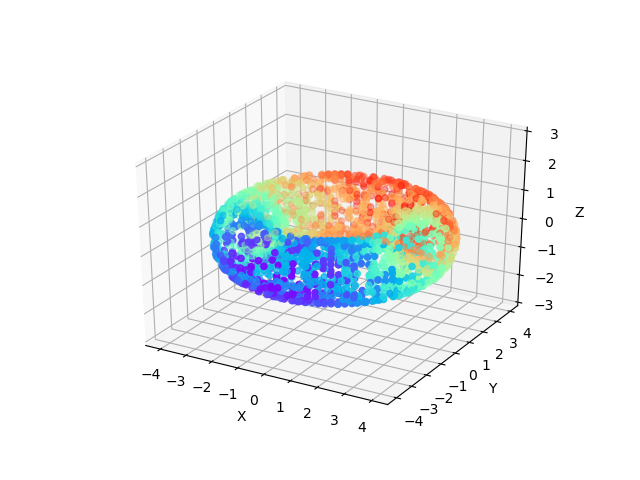

```python
c = 3
a = 1

# A parametric equation which takes two angles (measured in radians)
# and returns a vector which lies on the torus with parameters as specified above
def torus(u,v):
    x = (c + a*np.cos(v))*np.cos(u)
    y = (c + a*np.cos(v))*np.sin(u)
    z = a*np.sin(v)
    return np.array([x,y,z])

# We then generate n pairs of parameters (u,v) and compute the corresponding vectors for each, forming our point cloud
n = 2500
angleArray = np.linspace(0,2*np.pi,num=100)
Uangles = np.random.choice(angleArray, n)
Vangles = np.random.choice(angleArray, n)
pointsTorus = np.array([torus(u,v) for (u,v) in zip(Uangles,Vangles)])

# We shall take our filter function to be distance along the ( 0 = x-axis, 1 = y-axis, 2 = z-axis)
filtTorus = pointsTorus[:,1]

ax = plot_points(pointsTorus.T, filtTorus)
ax.set_zlim(-3,3)
plt.show()
```

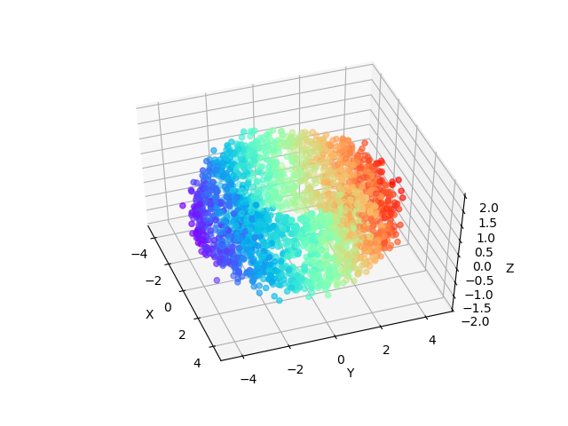

```python
pointsTorusNoise = np.array([pt + np.random.normal(loc = 0.0, scale = 0.2, size = 3) for pt in pointsTorus])
filtTorusNoise = pointsTorusNoise[:,1]

ax = plot_points(pointsTorusNoise.T, filtTorusNoise)
ax.set_zlim(-2,2)
plt.show()
```

These can be used to provide a very rough explanation of how the Mapper algorithm works. Imagine looking at all the points in a cloud of a particular colour. The idea is that these sub-clouds cluster in a way which represents the topology of the overall cloud. For example the red points on the bunny lie on the ears, thus form two distinct 'groups'. For another example, the green points on the torus form two distinct circles, whereas the red forms little more than an amorphous 'blob'. If we were to employ a nearest neighbour based clustering technique, we might end up with two clusters for the green circles, but just one for the red blob. A critical element of mapper is reducing these sub-clouds into a small number of points via clustering. Mathematically, each cluster becomes a node in a graph which is Mapper's output

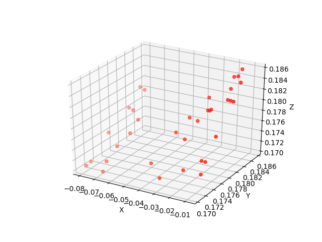

```python
bunBin = np.where(filtBun>0.24)
pointsBunBin = pointsBun.T[bunBin]
pointsBunBin = pointsBunBin.T
filtBunBin = filtBun[bunBin]

ax = plot_points(pointsBunBin, filtBunBin, filtNorm = colors.Normalize(vmin = min(filtBun), vmax = max(filtBun)))
plt.show()
```

Likewise, if we look at the green points on the torus:

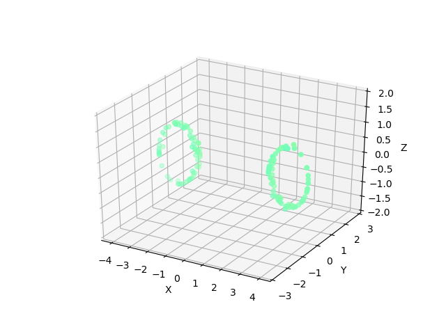

```python
torusBin = np.where(np.absolute(filtTorus) < 0.2)
pointsTorusBin = pointsTorus[torusBin]
pointsTorusBin = pointsTorusBin.T
filtTorusBin = filtTorus[torusBin]

ax = plot_points(pointsTorusBin, filtTorusBin, filtNorm = colors.Normalize(vmin = min(filtTorus), vmax = max(filtTorus)))
ax.set_zlim(-2,2)
ax.set_ylim(-3,3)
plt.show()
```

Mapper separates the point cloud in exactly this way, but importantly it includes some *overlap* in the so-called 'bins' (sub-clouds). For example, for the donut we might put teal points in both a blue bin and a green bin. It is precisely these points in the overlaps of bins which allow us to understand the global structure of the data. If a point is present in more than one bin, then Mapper connects both clusters which contain that point by an edge.

This means that the parameters needed when applying the Mapper algorithm to a dataset are:

1. The choice of filter function
2. The 'bins' a collection of overlapping intervals on the numberline according to which points are sorted using the filter function
3. A method of forming clusters for the point clouds in each bin

Before we spend more time talking about mapper, let's see what it does to the 'noisy donut':

```python
# Initialize
mapper = km.KeplerMapper(verbose=1)

# Fit to and transform the data
projected_data = mapper.fit_transform(pointsTorusNoise, projection=[1]) # Y axis

# Create dictionary called 'graph' with nodes, edges and meta-informationTorus
graph = mapper.map(projected_data,
                   pointsTorusNoise,
                   clusterer=sklearn.cluster.DBSCAN(eps = 0.5, min_samples=5),
                   coverer=km.Cover(nr_cubes=10, overlap_perc=0.3)
                  )

# Visualize it
_ = mapper.visualize(graph,
                 path_html="TorusNoise.html",
                 color_function = filtTorusNoise,
                 title="TorusNoise")
```

```
..Composing projection pipeline length 1:
Projections: [1]


Distance matrices: False


Scalers: MinMaxScaler(copy=True, feature_range=(0, 1))


..Projecting on data shaped (2500, 3)

..Projecting data using: [1]

..Scaling with: MinMaxScaler(copy=True, feature_range=(0, 1))

Mapping on data shaped (2500, 3) using lens shaped (2500, 1)

Creating 10 hypercubes.

Created 13 edges and 13 nodes in 0:00:00.166346.
Wrote visualization to: TorusNoise.html
```

## Graph Meta

### Nodes

13

### Edges

13

### Total Samples

3208

### Unique Samples

2492

### Distribution

0.0%

6.3%

24.0%

10.5%

5.5%

5.7%

10.4%

28.1%

7.8%

1.7%